# DADA2 - KelleyMicrobiome ITS2 Plate 1 & 2

```r
# if (!require("BiocManager", quietly = TRUE))
#     install.packages("BiocManager")
#
#BiocManager::install("phyloseq")
```

```r
library(tidyverse)
library(dada2)
library(ShortRead)
library(Biostrings)
library(phyloseq)
```

```r
seqDIR = '/project/mmicrobe/Kelley/ITS2/Raw/KY21-1-2'
path = seqDIR
list.files(path)
```

```
  [1] "1_1_1_S-Plate1F2_S14_L001_R1_001.fastq.gz"
  [2] "1_1_1_S-Plate1F2_S14_L001_R2_001.fastq.gz"
  [3] "1_1_2_S-Plate1H4_S32_L001_R1_001.fastq.gz"
  [4] "1_1_2_S-Plate1H4_S32_L001_R2_001.fastq.gz"
  [5] "1_1_3_S-Plate2H7_S151_L001_R1_001.fastq.gz"
  [6] "1_1_3_S-Plate2H7_S151_L001_R2_001.fastq.gz"
  [7] "1_1_5_S-Plate1G8_S63_L001_R1_001.fastq.gz"
  [8] "1_1_5_S-Plate1G8_S63_L001_R2_001.fastq.gz"
  [9] "1_2_1_S-Plate1E5_S37_L001_R1_001.fastq.gz"
 [10] "1_2_1_S-Plate1E5_S37_L001_R2_001.fastq.gz"
 [11] "1_2_2_S-Plate1G3_S23_L001_R1_001.fastq.gz"
 [12] "1_2_2_S-Plate1G3_S23_L001_R2_001.fastq.gz"
 [13] "1_2_3_S-Plate2D3_S115_L001_R1_001.fastq.gz"
 [14] "1_2_3_S-Plate2D3_S115_L001_R2_001.fastq.gz"
 [15] "1_2_5_S-Plate1E7_S53_L001_R1_001.fastq.gz"
```

[output cut: 367 more lines]

# Collect files

```r
#Collect forward and reverse names in order
fnFs <- sort(list.files(path, pattern = "_R1_001.fastq.gz", full.names = TRUE))
fnRs <- sort(list.files(path, pattern = "_R2_001.fastq.gz", full.names = TRUE))
if(length(fnFs) != length(fnRs)) stop("Forward and reverse files do not match.")
```

# Identify primers

```r
FWD <- "AACTTTYRRCAAYGGATCWCT"  ## ITS2 5.8S forward primer sequence
REV <- "AGCCTCCGCTTATTGATATGCTTAART"  ## ITS2 ITS4Fun primer sequence
FSEQ = "TCTTTCCCTACACGACGCTCTTCCGATCT" # Forward sequencing primer
RSEQ = "GTGACTGGAGTTCAGACGTGTGCTCTTCCGATCT" # Reverse sequencing primer
```

```r
allOrients <- function(primer) {
    # Create all orientations of the input sequence
    require(Biostrings)
    dna <- DNAString(primer)  # The Biostrings works w/ DNAString objects rather than character vectors
    orients <- c(Forward = dna, Complement = Biostrings::complement(dna), Reverse = Biostrings::reverse(dna),
        RevComp = Biostrings::reverseComplement(dna))
    return(sapply(orients, toString))  # Convert back to character vector
}
FWD.orients <- allOrients(FWD)
REV.orients <- allOrients(REV)
FSEQ.orients <- allOrients(FSEQ)
RSEQ.orients <- allOrients(RSEQ)
FWD.orients
```

```
                Forward              Complement
"AACTTTYRRCAAYGGATCWCT" "TTGAAARYYGTTRCCTAGWGA"
                Reverse                 RevComp
"TCWCTAGGYAACRRYTTTCAA" "AGWGATCCRTTGYYRAAAGTT"
```

```r
REV.orients
```

```
                      Forward
"AGCCTCCGCTTATTGATATGCTTAART"
                   Complement
"TCGGAGGCGAATAACTATACGAATTYA"
                      Reverse
"TRAATTCGTATAGTTATTCGCCTCCGA"
                      RevComp
"AYTTAAGCATATCAATAAGCGGAGGCT"
```

```r
FSEQ.orients
```

```
                        Forward
"TCTTTCCCTACACGACGCTCTTCCGATCT"
                     Complement
"AGAAAGGGATGTGCTGCGAGAAGGCTAGA"
                        Reverse
"TCTAGCCTTCTCGCAGCACATCCCTTTCT"
                        RevComp
"AGATCGGAAGAGCGTCGTGTAGGGAAAGA"
```

```r
RSEQ.orients
```

```
                             Forward
"GTGACTGGAGTTCAGACGTGTGCTCTTCCGATCT"
                          Complement
"CACTGACCTCAAGTCTGCACACGAGAAGGCTAGA"
                             Reverse
"TCTAGCCTTCTCGTGTGCAGACTTGAGGTCAGTG"
                             RevComp
"AGATCGGAAGAGCACACGTCTGAACTCCAGTCAC"
```

```r
if (file.exists(file.path(path, "filtN"))){
  print(TRUE)
} else {
  #create new subdirectory
  dir.create(file.path(path,"filtN"))
}
```

```r
fnFs.filtN <- file.path(path, "filtN", basename(fnFs)) # Put N-filtered files in filtN/ subdirectory
fnRs.filtN <- file.path(path, "filtN", basename(fnRs))
filterAndTrim(fnFs, fnFs.filtN, fnRs, fnRs.filtN, maxN = 0, multithread = ncores)

fnFs.filtN[1]
```

```
[1] "/project/mmicrobe/Kelley/ITS2/Raw/KY21-1-2/filtN/1_1_1_S-Plate1F2_S14_L001_R1_001.fastq.gz"
```

```r
fnRs.filtN[1]
```

```
[1] "/project/mmicrobe/Kelley/ITS2/Raw/KY21-1-2/filtN/1_1_1_S-Plate1F2_S14_L001_R2_001.fastq.gz"
```

## Check orientation and read through

```r
primerHits <- function(primer, fn) {
    # Counts number of reads in which the primer is found
    nhits <- vcountPattern(primer, sread(readFastq(fn)), fixed = FALSE)
    return(sum(nhits > 0))
}
rbind(
  FWD.ForwardReads = sapply(FWD.orients, primerHits, fn = fnFs.filtN[[7]]),
  FWD.ReverseReads = sapply(FWD.orients,
    primerHits, fn = fnRs.filtN[[7]]),
  REV.ForwardReads = sapply(REV.orients, primerHits,
    fn = fnFs.filtN[[7]]),
  REV.ReverseReads = sapply(REV.orients, primerHits, fn = fnRs.filtN[[7]]))
```

```
                 Forward Complement Reverse RevComp
FWD.ForwardReads   38670          0       0       0
FWD.ReverseReads       0          0       0     264
REV.ForwardReads       0          0       0     343
REV.ReverseReads   37544          0       0       0
```

Some primer read through

Check for the sequencing adapters to see if there are similar counts

```r
rbind(
  FSEQ.ForwardReads = sapply(FSEQ.orients, primerHits, fn = fnFs.filtN[[7]]),
  FSEQ.ReverseReads = sapply(FSEQ.orients,
    primerHits, fn = fnRs.filtN[[7]]),
  RSEQ.ForwardReads = sapply(RSEQ.orients, primerHits,
    fn = fnFs.filtN[[7]]),
  RSEQ.ReverseReads = sapply(RSEQ.orients, primerHits, fn = fnRs.filtN[[7]]))
```

```
                  Forward Complement Reverse RevComp
FSEQ.ForwardReads       0          0       0       0
FSEQ.ReverseReads       0          0       0     846
RSEQ.ForwardReads       0          0       0    1134
RSEQ.ReverseReads       0          0       0       0
```

Some sequencing primers present

# Execute cutadapt from bash script through ssh

The system command was not working properly, Use R to generate adapter and RC sequences

```r
# cutadapt <- "/home/bryan.emmett/.local/bin/cutadapt"
# system2(command = cutadapt, args = "--version")
```

### Create directory for trimmed sequences

```r
path.cut <- file.path(path, "cutadapt")
if(!dir.exists(path.cut)) dir.create(path.cut)
fnFs.cut <- file.path(path.cut, basename(fnFs))
fnRs.cut <- file.path(path.cut, basename(fnRs))
```

### Define primers

```r
FWD.RC <- dada2:::rc(FWD)
REV.RC <- dada2:::rc(REV)
FWD
```

```
[1] "AACTTTYRRCAAYGGATCWCT"
```

```r
REV
```

```
[1] "AGCCTCCGCTTATTGATATGCTTAART"
```

```r
FWD.RC
```

```
[1] "AGWGATCCRTTGYYRAAAGTT"
```

```r
REV.RC
```

```
[1] "AYTTAAGCATATCAATAAGCGGAGGCT"
```

```r
R1.flags <- paste("-g", FWD, "-a", REV.RC)
R2.flags <- paste("-G", REV, "-A", FWD.RC)
R1.flags
```

```
[1] "-g AACTTTYRRCAAYGGATCWCT -a AYTTAAGCATATCAATAAGCGGAGGCT"
```

```r
R2.flags
```

```
[1] "-G AGCCTCCGCTTATTGATATGCTTAART -A AGWGATCCRTTGYYRAAAGTT"
```

then ran bash_cutadapt.sh script. Note to run using sbatch in order to run job on compute node.

```r
fnRs.cut[1]
```

```
[1] "/project/mmicrobe/Kelley/ITS2/Raw/KY21-1-2/cutadapt/1_1_1_S-Plate1F2_S14_L001_R2_001.fastq.gz"
```

## Check cut adapt

```r
rbind(FWD.ForwardReads = sapply(FWD.orients, primerHits, fn = fnFs.cut[[1]]), FWD.ReverseReads = sapply(FWD.orients,
    primerHits, fn = fnRs.cut[[1]]), REV.ForwardReads = sapply(REV.orients, primerHits,
    fn = fnFs.cut[[1]]), REV.ReverseReads = sapply(REV.orients, primerHits, fn = fnRs.cut[[1]]))
```

```
                 Forward Complement Reverse RevComp
FWD.ForwardReads       0          0       0       0
FWD.ReverseReads       0          0       0       0
REV.ForwardReads       0          0       0       0
REV.ReverseReads       0          0       0       0
```

Check for the sequencing adapters to see if there are similar counts

```r
rbind(
  FSEQ.ForwardReads = sapply(FSEQ.orients, primerHits, fn = fnFs.cut[[1]]),
  FSEQ.ReverseReads = sapply(FSEQ.orients,
    primerHits, fn = fnRs.cut[[1]]),
  RSEQ.ForwardReads = sapply(RSEQ.orients, primerHits,
    fn = fnFs.cut[[1]]),
  RSEQ.ReverseReads = sapply(RSEQ.orients, primerHits, fn = fnRs.cut[[1]]))
```

```
                  Forward Complement Reverse RevComp
FSEQ.ForwardReads       0          0       0       0
FSEQ.ReverseReads       0          0       0     507
RSEQ.ForwardReads       0          0       0      14
RSEQ.ReverseReads       0          0       0       0
```

Some sequences remain with sequencing primers. Need to re-run cut-adapt and include adapter sequences and filter for fragments smaller than a certain size.

## Check after second cutadapt round

changing path to cut files to target new cutadapt2 folder

```r
path.cut2 <- file.path(path, "cutadapt2")
#if(!dir.exists(path.cut)) dir.create(path.cut)
fnFs.cut <- file.path(path.cut2, basename(fnFs))
fnRs.cut <- file.path(path.cut2, basename(fnRs))
```

```r
fnFs.cut[1]
```

```
[1] "/project/mmicrobe/Kelley/ITS2/Raw/KY21-1-2/cutadapt2/1_1_1_S-Plate1F2_S14_L001_R1_001.fastq.gz"
```

```r
rbind(
  FSEQ.ForwardReads = sapply(FSEQ.orients, primerHits, fn = fnFs.cut[[1]]),
  FSEQ.ReverseReads = sapply(FSEQ.orients,
    primerHits, fn = fnRs.cut[[1]]),
  RSEQ.ForwardReads = sapply(RSEQ.orients, primerHits,
    fn = fnFs.cut[[1]]),
  RSEQ.ReverseReads = sapply(RSEQ.orients, primerHits, fn = fnRs.cut[[1]]))
```

```
                  Forward Complement Reverse RevComp
FSEQ.ForwardReads       0          0       0       0
FSEQ.ReverseReads       0          0       0       0
RSEQ.ForwardReads       0          0       0       0
RSEQ.ReverseReads       0          0       0       0
```

```r
# Forward and reverse fastq filenames have the format:
cutFs <- sort(list.files(path.cut2, pattern = "_R1_001.fastq.gz", full.names = TRUE))
cutRs <- sort(list.files(path.cut2, pattern = "_R2_001.fastq.gz", full.names = TRUE))

# Extract sample names, assuming filenames have format:
get.sample.name <- function(fname) strsplit(basename(fname), "_L001")[[1]][1]
sample.names <- unname(sapply(cutFs, get.sample.name))


sample.names
```

```
  [1] "1_1_1_S-Plate1F2_S14"
  [2] "1_1_2_S-Plate1H4_S32"
  [3] "1_1_3_S-Plate2H7_S151"
  [4] "1_1_5_S-Plate1G8_S63"
  [5] "1_2_1_S-Plate1E5_S37"
  [6] "1_2_2_S-Plate1G3_S23"
  [7] "1_2_3_S-Plate2D3_S115"
  [8] "1_2_5_S-Plate1E7_S53"
  [9] "1_x_1_Rh-Plate2B11_S177"
 [10] "1_x_2_Rh-Plate2A1_S96"
 [11] "1_x_3_Rh-Plate2E9_S164"
 [12] "1_x_4_Rh-Plate1C11_S83"
 [13] "11_1_1_S-Plate1A3_S17"
 [14] "11_1_2_S-Plate2H2_S111"
 [15] "11_1_3_S-Plate1C4_S27"
```

[output cut: 176 more lines]

# Plot quality profiles and forward and reverse reads

## Forward reads

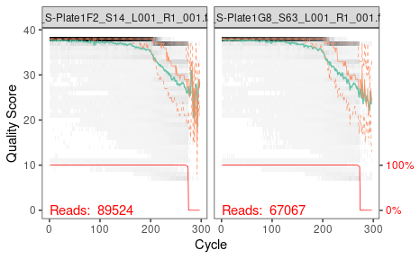

```r
plotQualityProfile(fnFs.cut[c(1,4)])
```

Forward reads are high quality

## Reverse reads

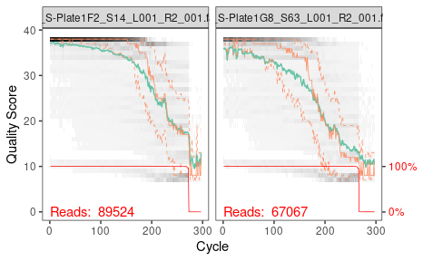

```r
plotQualityProfile(fnRs.cut[c(1,4)])
```

- Reverse reads decrease in quality around 200 bp

## Last check

```r
readLines(fnFs.cut[1], n = 4)
```

```
[1] "@M01479:492:000000000-L8RKW:1:1101:15484:1701 1:N:0:CTCCCATA+TACCGGCT"
[2] "TGGCTCTCGCATCGATGAAGAACGCAGCGAAATGCGATAAGTAATGTGAATTGCAGAATT…"
[3] "+"
[4] "GGGGGGGGGGGGGGGGGGGGGGGGGGGGGGGGGGGGGGGGGGGGGGGGGGGGGGGGGGGGGGGGGGGGGGGGGGGGGGGGGGGGGGGGGGGGGGGGGGGGGGGGGGGGGGGGGGGGGGGGGGGGGGGGGGGGGGGGGGGGGGGGGGGGGGGGGGFFGGGGDCFGGGGGGGD6CA>DFFFFFFGFDEGFFFFFFFEFFFFFFFFFFFFFFFFAE1@FFEFFEFF3?5<EFFFFFFFF6::99BF<).-.).<?AFF?A<>A2<AAAA<2:B1019"
```

```r
readLines(fnRs.cut[1], n = 4)
```

```
[1] "@M01479:492:000000000-L8RKW:1:1101:15484:1701 2:N:0:CTCCCATA+TACCGGCT"
[2] "TCAGCGGGTAGTCTTACCTGATTTGAGGTCAAAATTGTCAAGAGTTGTCCGGTGAAGGAC…"
[3] "+"
[4] "FGGGGGGGGGGGGGGGGGGGGGGGFGGGGGGGGGGGGGGGGGGGGGFFGGGGGGGFGGGGGGGGE??FEFGGGGGGGGGAEGGFGGGGGGGFFGGGGGGECEEGGGGGCFGGGGGGGGGEEFGFGCECFGDGG68CGCGGG7CGGGGFGGF7CCDD*;7*<;CFFA4?9A>9=A/5??CFFFF;FDD)8AF;E8E;3=D14338)=@3333;(/2(,((((-(()0,).).22>)))))6)(,228:(402(((.((44((((-(.3<?),("
```

```r
#path
#fastqFs[1]
```

# Filter and trim

```r
filtFs <- file.path(path.cut2, "filtered", basename(cutFs))
filtRs <- file.path(path.cut2, "filtered", basename(cutRs))
```

```r
out <- filterAndTrim(cutFs, filtFs, cutRs, filtRs, maxN = 0, maxEE = c(2, 2), truncQ = 8,
    minLen = 50, rm.phix = TRUE, compress = TRUE, multithread = ncores)  # on windows, set multithread = FALSE
```

```
Creating output directory: /project/mmicrobe/Kelley/ITS2/Raw/KY21-1-2/cutadapt2/filtered
```

```r
head(out)
```

```
                                           reads.in
1_1_1_S-Plate1F2_S14_L001_R1_001.fastq.gz     89524
1_1_2_S-Plate1H4_S32_L001_R1_001.fastq.gz     87292
1_1_3_S-Plate2H7_S151_L001_R1_001.fastq.gz    82460
1_1_5_S-Plate1G8_S63_L001_R1_001.fastq.gz     67067
1_2_1_S-Plate1E5_S37_L001_R1_001.fastq.gz     53133
1_2_2_S-Plate1G3_S23_L001_R1_001.fastq.gz     57631
                                           reads.out
1_1_1_S-Plate1F2_S14_L001_R1_001.fastq.gz      80749
1_1_2_S-Plate1H4_S32_L001_R1_001.fastq.gz      78348
1_1_3_S-Plate2H7_S151_L001_R1_001.fastq.gz     74474
1_1_5_S-Plate1G8_S63_L001_R1_001.fastq.gz      50043
1_2_1_S-Plate1E5_S37_L001_R1_001.fastq.gz      47034
1_2_2_S-Plate1G3_S23_L001_R1_001.fastq.gz      41576
```

```r
head(out)
```

```
                                           reads.in
1_1_1_S-Plate1F2_S14_L001_R1_001.fastq.gz     89524
1_1_2_S-Plate1H4_S32_L001_R1_001.fastq.gz     87292
1_1_3_S-Plate2H7_S151_L001_R1_001.fastq.gz    82460
1_1_5_S-Plate1G8_S63_L001_R1_001.fastq.gz     67067
1_2_1_S-Plate1E5_S37_L001_R1_001.fastq.gz     53133
1_2_2_S-Plate1G3_S23_L001_R1_001.fastq.gz     57631
                                           reads.out
1_1_1_S-Plate1F2_S14_L001_R1_001.fastq.gz      80749
1_1_2_S-Plate1H4_S32_L001_R1_001.fastq.gz      78348
1_1_3_S-Plate2H7_S151_L001_R1_001.fastq.gz     74474
1_1_5_S-Plate1G8_S63_L001_R1_001.fastq.gz      50043
1_2_1_S-Plate1E5_S37_L001_R1_001.fastq.gz      47034
1_2_2_S-Plate1G3_S23_L001_R1_001.fastq.gz      41576
```

```r
OutFolder = "/project/mmicrobe/Kelley/ITS2/KY21-1-2/"
saveRDS(out, file.path(OutFolder,'FilterTrim.rds'))
```

# Remove failed samples to avoid downstream problems

Note that ExBlank1b-Plate1E12 is actually sample 14_x_3_Rh, which was mistakenly thought to be a blank downstream. It was also normalized to cell A1, so there is a duplicate to compare and confirm.

|  | reads.in | reads.out |
| --- | --- | --- |
| 1_x_1_Rh-Plate2B11_S177_L001_R1_001.fastq.gz | 9 | 6 |
| 11_x_1_Rh-Plate2C11_S178_L001_R1_001.fastq.gz | 14 | 11 |
| 16_x_4_Rh-Plate2B12_S185_L001_R1_001.fastq.gz | 5 | 3 |
| 22_x_4_Rh-Plate2C12_S186_L001_R1_001.fastq.gz | 7 | 2 |
| 23_x_4_Rh-Plate2A12_S184_L001_R1_001.fastq.gz | 3 | 3 |
| 9_x_3_Rh-Plate1F11_S86_L001_R1_001.fastq.gz | 16 | 11 |
| PCRBlank2-Plate2F12_S189_L001_R1_001.fastq.gz | 12 | 10 |

maybe it is ok, leave in for now

# Learn errors

```r
set.seed(100)
# Learn forward error rates
errF <- learnErrors(filtFs, multithread = ncores)
```

```
103577013 total bases in 407084 reads from 7 samples will be used for learning the error rates.
```

```r
# Learn reverse error rates
errR <- learnErrors(filtRs, multithread=ncores)
```

```
110203303 total bases in 545020 reads from 11 samples will be used for learning the error rates.
```

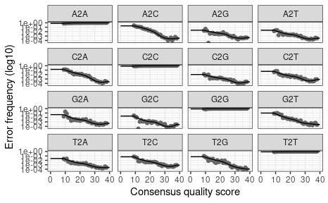

```r
plotErrors(errF)
```

```r
errF_File = file.path(OutFolder,"errF.rds")
saveRDS(errF, errF_File)

errR_File = file.path(OutFolder,"errR.rds")
saveRDS(errR, errR_File)
```

# Sequence Inference

```r
dadaFs <- dada(filtFs, err = errF, multithread = TRUE)
```

```
Sample 1 - 80749 reads in 21419 unique sequences.
Sample 2 - 78348 reads in 21572 unique sequences.
Sample 3 - 74474 reads in 18192 unique sequences.
Sample 4 - 50043 reads in 12763 unique sequences.
Sample 5 - 47034 reads in 15381 unique sequences.
Sample 6 - 41576 reads in 10649 unique sequences.
Sample 7 - 34860 reads in 10915 unique sequences.
Sample 8 - 30896 reads in 9713 unique sequences.
Sample 9 - 6 reads in 6 unique sequences.
Sample 10 - 49 reads in 45 unique sequences.
Sample 11 - 106985 reads in 24242 unique sequences.
Sample 12 - 58401 reads in 17166 unique sequences.
Sample 13 - 86625 reads in 31410 unique sequences.
Sample 14 - 129466 reads in 33410 unique sequences.
Sample 15 - 76694 reads in 22668 unique sequences.
Sample 16 - 58481 reads in 18595 unique sequences.
Sample 17 - 92889 reads in 27039 unique sequences.
Sample 18 - 44531 reads in 12272 unique sequences.
Sample 19 - 41975 reads in 12201 unique sequences.
Sample 20 - 64150 reads in 18968 unique sequences.
Sample 21 - 11 reads in 11 unique sequences.
Sample 22 - 34765 reads in 7596 unique sequences.
Sample 23 - 34716 reads in 11683 unique sequences.
Sample 24 - 157739 reads in 34732 unique sequences.
Sample 25 - 53424 reads in 14854 unique sequences.
Sample 26 - 38783 reads in 10005 unique sequences.
Sample 27 - 50290 reads in 14364 unique sequences.
Sample 28 - 71710 reads in 18248 unique sequences.
Sample 29 - 6618 reads in 2979 unique sequences.
Sample 30 - 33610 reads in 11732 unique sequences.
Sample 31 - 49556 reads in 15987 unique sequences.
Sample 32 - 62419 reads in 16558 unique sequences.
Sample 33 - 67931 reads in 20988 unique sequences.
Sample 34 - 53690 reads in 15196 unique sequences.
Sample 35 - 66483 reads in 17153 unique sequences.
Sample 36 - 82101 reads in 20215 unique sequences.
Sample 37 - 61314 reads in 17666 unique sequences.
Sample 38 - 56771 reads in 14307 unique sequences.
Sample 39 - 17461 reads in 6546 unique sequences.
Sample 40 - 40162 reads in 12947 unique sequences.
```

[output cut: 136 more lines]

```
Sample 177 - 4351 reads in 2039 unique sequences.
Sample 178 - 46330 reads in 14184 unique sequences.
Sample 179 - 44522 reads in 13160 unique sequences.
Sample 180 - 58243 reads in 17038 unique sequences.
Sample 181 - 117 reads in 102 unique sequences.
Sample 182 - 11 reads in 11 unique sequences.
Sample 183 - 1165 reads in 611 unique sequences.
Sample 184 - 27156 reads in 9739 unique sequences.
Sample 185 - 1141 reads in 671 unique sequences.
Sample 186 - 46 reads in 27 unique sequences.
Sample 187 - 180553 reads in 36167 unique sequences.
Sample 188 - 331931 reads in 71313 unique sequences.
Sample 189 - 38 reads in 23 unique sequences.
Sample 190 - 10 reads in 7 unique sequences.
Sample 191 - 430804 reads in 142624 unique sequences.
```

```r
dadaRs <- dada(filtRs, err = errR, multithread = TRUE)
```

```
Sample 1 - 80749 reads in 34087 unique sequences.
Sample 2 - 78348 reads in 35202 unique sequences.
Sample 3 - 74474 reads in 32105 unique sequences.
Sample 4 - 50043 reads in 28858 unique sequences.
Sample 5 - 47034 reads in 25504 unique sequences.
Sample 6 - 41576 reads in 25366 unique sequences.
Sample 7 - 34860 reads in 17405 unique sequences.
Sample 8 - 30896 reads in 15728 unique sequences.
Sample 9 - 6 reads in 6 unique sequences.
Sample 10 - 49 reads in 49 unique sequences.
Sample 11 - 106985 reads in 36598 unique sequences.
Sample 12 - 58401 reads in 22346 unique sequences.
Sample 13 - 86625 reads in 40115 unique sequences.
Sample 14 - 129466 reads in 51611 unique sequences.
Sample 15 - 76694 reads in 32033 unique sequences.
Sample 16 - 58481 reads in 28751 unique sequences.
Sample 17 - 92889 reads in 41697 unique sequences.
Sample 18 - 44531 reads in 28094 unique sequences.
Sample 19 - 41975 reads in 20475 unique sequences.
Sample 20 - 64150 reads in 30573 unique sequences.
Sample 21 - 11 reads in 11 unique sequences.
Sample 22 - 34765 reads in 13906 unique sequences.
Sample 23 - 34716 reads in 17017 unique sequences.
Sample 24 - 157739 reads in 50135 unique sequences.
Sample 25 - 53424 reads in 28100 unique sequences.
Sample 26 - 38783 reads in 25762 unique sequences.
Sample 27 - 50290 reads in 23882 unique sequences.
Sample 28 - 71710 reads in 31809 unique sequences.
Sample 29 - 6618 reads in 4819 unique sequences.
Sample 30 - 33610 reads in 18671 unique sequences.
Sample 31 - 49556 reads in 26115 unique sequences.
Sample 32 - 62419 reads in 29779 unique sequences.
Sample 33 - 67931 reads in 32576 unique sequences.
Sample 34 - 53690 reads in 21961 unique sequences.
Sample 35 - 66483 reads in 30388 unique sequences.
Sample 36 - 82101 reads in 35853 unique sequences.
Sample 37 - 61314 reads in 27708 unique sequences.
Sample 38 - 56771 reads in 27097 unique sequences.
Sample 39 - 17461 reads in 10373 unique sequences.
Sample 40 - 40162 reads in 20972 unique sequences.
```

[output cut: 136 more lines]

```
Sample 177 - 4351 reads in 3126 unique sequences.
Sample 178 - 46330 reads in 23418 unique sequences.
Sample 179 - 44522 reads in 20861 unique sequences.
Sample 180 - 58243 reads in 27098 unique sequences.
Sample 181 - 117 reads in 109 unique sequences.
Sample 182 - 11 reads in 11 unique sequences.
Sample 183 - 1165 reads in 927 unique sequences.
Sample 184 - 27156 reads in 13913 unique sequences.
Sample 185 - 1141 reads in 966 unique sequences.
Sample 186 - 46 reads in 44 unique sequences.
Sample 187 - 180553 reads in 61431 unique sequences.
Sample 188 - 331931 reads in 69762 unique sequences.
Sample 189 - 38 reads in 35 unique sequences.
Sample 190 - 10 reads in 9 unique sequences.
Sample 191 - 430804 reads in 193794 unique sequences.
```

# Merge paired end reads

```r
mergers <- mergePairs(dadaFs, filtFs, dadaRs, filtRs, verbose=TRUE)
```

```
73568 paired-reads (in 256 unique pairings) successfully merged out of 79973 (in 474 pairings) input.
Duplicate sequences in merged output.
68340 paired-reads (in 315 unique pairings) successfully merged out of 77236 (in 558 pairings) input.
Duplicate sequences in merged output.
67831 paired-reads (in 267 unique pairings) successfully merged out of 73613 (in 431 pairings) input.
44570 paired-reads (in 216 unique pairings) successfully merged out of 48590 (in 367 pairings) input.
Duplicate sequences in merged output.
41730 paired-reads (in 228 unique pairings) successfully merged out of 45740 (in 435 pairings) input.
Duplicate sequences in merged output.
36663 paired-reads (in 207 unique pairings) successfully merged out of 40608 (in 322 pairings) input.
Duplicate sequences in merged output.
31249 paired-reads (in 183 unique pairings) successfully merged out of 34474 (in 268 pairings) input.
Duplicate sequences in merged output.
27949 paired-reads (in 183 unique pairings) successfully merged out of 30155 (in 277 pairings) input.
Duplicate sequences in merged output.
No paired-reads (in ZERO unique pairings) successfully merged out of 6 pairings) input.
8 paired-reads (in 1 unique pairings) successfully merged out of 8 (in 1 pairings) input.
101542 paired-reads (in 209 unique pairings) successfully merged out of 105871 (in 428 pairings) input.
54425 paired-reads (in 188 unique pairings) successfully merged out of 57206 (in 371 pairings) input.
Duplicate sequences in merged output.
75061 paired-reads (in 333 unique pairings) successfully merged out of 84440 (in 949 pairings) input.
Duplicate sequences in merged output.
119283 paired-reads (in 344 unique pairings) successfully merged out of 127730 (in 946 pairings) input.
Duplicate sequences in merged output.
63893 paired-reads (in 259 unique pairings) successfully merged out of 75395 (in 514 pairings) input.
Duplicate sequences in merged output.
50018 paired-reads (in 270 unique pairings) successfully merged out of 57213 (in 519 pairings) input.
Duplicate sequences in merged output.
83828 paired-reads (in 333 unique pairings) successfully merged out of 91766 (in 624 pairings) input.
Duplicate sequences in merged output.
38245 paired-reads (in 200 unique pairings) successfully merged out of 42987 (in 400 pairings) input.
37285 paired-reads (in 177 unique pairings) successfully merged out of 40601 (in 374 pairings) input.
Duplicate sequences in merged output.
58372 paired-reads (in 261 unique pairings) successfully merged out of 62944 (in 453 pairings) input.
Duplicate sequences in merged output.
No paired-reads (in ZERO unique pairings) successfully merged out of 11 pairings) input.
31833 paired-reads (in 79 unique pairings) successfully merged out of 34146 (in 160 pairings) input.
Duplicate sequences in merged output.
31380 paired-reads (in 149 unique pairings) successfully merged out of 33787 (in 299 pairings) input.
148583 paired-reads (in 334 unique pairings) successfully merged out of 155751 (in 725 pairings) input.
```

[output cut: 251 more lines]

```
52916 paired-reads (in 231 unique pairings) successfully merged out of 57008 (in 432 pairings) input.
Duplicate sequences in merged output.
59 paired-reads (in 1 unique pairings) successfully merged out of 59 (in 1 pairings) input.
No paired-reads (in ZERO unique pairings) successfully merged out of 11 pairings) input.
832 paired-reads (in 23 unique pairings) successfully merged out of 1058 (in 27 pairings) input.
23873 paired-reads (in 124 unique pairings) successfully merged out of 26066 (in 259 pairings) input.
Duplicate sequences in merged output.
638 paired-reads (in 15 unique pairings) successfully merged out of 863 (in 27 pairings) input.
27 paired-reads (in 1 unique pairings) successfully merged out of 27 (in 1 pairings) input.
171348 paired-reads (in 319 unique pairings) successfully merged out of 180050 (in 578 pairings) input.
310034 paired-reads (in 526 unique pairings) successfully merged out of 331052 (in 980 pairings) input.
31 paired-reads (in 1 unique pairings) successfully merged out of 31 (in 1 pairings) input.
5 paired-reads (in 1 unique pairings) successfully merged out of 5 (in 1 pairings) input.
375423 paired-reads (in 884 unique pairings) successfully merged out of 417936 (in 2379 pairings) input.
Duplicate sequences in merged output.
```

## Construct sequence table

##3 Checkpoint - read mergers file, construct sequence table and remove chimeras

```r
seqtab <- makeSequenceTable(mergers)
```

[output not shown]

[output cut: 60 more lines]

[output not shown]

```r
dim(seqtab)
```

```
[1]  191 6923
```

## Remove chimeras

```r
seqtab.nochim <- removeBimeraDenovo(seqtab, method="consensus", multithread=ncores, verbose=TRUE)
```

```r
dim(seqtab.nochim)
```

[output not shown]

```r
# Inspect distribution of sequence lengths
table(nchar(getSequences(seqtab.nochim)))
```

```
 50  51  52  53  55  58  69  80
  1   1   1   1   1   1   1   1
 83  88 106 141 200 205 216 223
  1   1   1   1   1   2   1   1
226 227 228 230 235 237 241 243
  3   1   2   1   2   2   1   2
244 245 247 248 250 251 252 254
  3   1   1   1   3   1   1   1
255 256 258 261 264 265 266 267
  1   3   2   1   1   2   1   1
268 270 272 273 274 275 277 278
  3   1   1   3   1   1   3   2
279 280 281 282 284 285 286 287
  2   1   1   4   3   5   5   1
288 289 291 292 293 294 295 296
```

[output cut: 57 more lines]

```r
outFile = file.path(OutFolder,"seqtab-nochim.rds")

saveRDS(seqtab.nochim, outFile)
```

## Checkpoint read seqtab.nochim

```r
CheckPoint = file.path(OutFolder,"seqtab-nochim.rds")

seqtab.nochim = readRDS(CheckPoint)
```

```r
paste("Fraction of reads not attributed to chimeras:", sum(seqtab.nochim)/sum(seqtab))
```

```
[1] "Fraction of reads not attributed to chimeras: 0.950286724436818"
```

# Track reads through pipeline

```r
getN <- function(x) sum(getUniques(x))
track <- cbind(out, sapply(dadaFs, getN), sapply(dadaRs, getN), sapply(mergers, getN),
    rowSums(seqtab.nochim))
```

[output not shown]

[output cut: 26 more lines]

[output not shown]

```r
# If processing a single sample, remove the sapply calls: e.g. replace
# sapply(dadaFs, getN) with getN(dadaFs)
colnames(track) <- c("input", "filtered", "denoisedF", "denoisedR", "merged", "nonchim")
#rownames(track) <- sample.names
head(track)
```

[output not shown]

```r
track %>% as.data.frame() %>% mutate(sample = row.names(.)) %>% dplyr::arrange(desc(nonchim))
```

[output not shown]

[output cut: 147 more lines]

```r
outFile = file.path(OutFolder,'Tracking.txt')
write.table(track, file = outFile, sep = "\t")
```

### double check

```r
dim(seqtab.nochim)
```

[output not shown]

```r
dim(st2)
```

```
[1]  157 5008
```

```r
outFile = file.path(OutFolder,"st2.rds")

saveRDS(st2, outFile)
```

# Attempted to run through this point, confirm that chunks up above ran well before moving on.

### Clean up memory

```r
rm(ddF, ddR, errF, errR, merger, mergers, out, seqtab, seqtab.nochim, seqtab2, track)
rm(st2)
```

# Stop here to merge files from two MiSeq runs in notebook 2

# Checkpoint

```r
CheckPoint = file.path(OutFolder,"st2.rds")

seqtab.nochim = readRDS(CheckPoint)
```

```r
seqtab.nochim[1:10,1:10]
```

[output not shown]

[output cut: 93 more lines]

# Assign Taxonomy

Assigning taxonomy using the UNITE database

```r
unite.ref <- "/project/mmicrobe/databases/sh_general_release_dynamic_18.07.2023.fasta"  # CHANGE ME to location on your machine
taxa <- assignTaxonomy(seqtab.nochim, unite.ref, multithread = ncores, tryRC = TRUE)
```

```
UNITE fungal taxonomic reference detected.
```

```r
taxa.print <- taxa  # Removing sequence rownames for display only
rownames(taxa.print) <- NULL
head(taxa.print)
```

```
     Kingdom    Phylum
[1,] "k__Fungi" "p__Fungi_phy_Incertae_sedis"
[2,] "k__Fungi" "p__Ascomycota"
[3,] "k__Fungi" "p__Ascomycota"
[4,] "k__Fungi" "p__Ascomycota"
[5,] "k__Fungi" "p__Ascomycota"
[6,] "k__Fungi" "p__Ascomycota"
     Class
[1,] "c__Fungi_cls_Incertae_sedis"
[2,] "c__Sordariomycetes"
[3,] "c__Sordariomycetes"
[4,] "c__Leotiomycetes"
[5,] "c__Dothideomycetes"
[6,] "c__Sordariomycetes"
     Order
```

[output cut: 20 more lines]

```r
outFile = file.path(OutFolder,'taxa.rds')
outFile
```

[output not shown]

```r
saveRDS(taxa, outFile)
```

# Checkpoint read taxa file

```r
CheckPoint = file.path(OutFolder,"taxa.rds")
taxa = readRDS(CheckPoint)
```

```r
dim(taxa)
```

```
[1] 5008    7
```

# Resume here need metadata file

# Hand off to phyloseq

```r
# read sample data
SamTab = "/project/mmicrobe/MLSH/ITS2/MLSH_ITSMap.csv"
samdf = read.delim(file = SamTab, header = TRUE, sep = ',')
head(samdf)
row.names(samdf) = samdf$Sample.ID
samdf = samdf[,-3]
rownames(samdf)[1:4]
```

```r
dim(samdf)
```

```r
colnames(taxa)
#rename taxa
taxa = cbind(taxa, row.names(taxa))

colnames(taxa)[8] = "Seq"
```

##fix sample names

```r
NewNames = rownames(seqtab.nochim)

#NewNames=strsplit(NewNames, "_S", 1)
NewNames = str_split(NewNames, "_S", simplify = TRUE)[,1]

rownames(seqtab.nochim) = NewNames
#NewNames
```

```r
rownames(seqtab.nochim) %>% length()
```

```r
rownames(samdf) %>% length
```

Empty samples were removed in pipeline, remove them here. In other datasets there may be samples that need to be removed from the sequencing set that aren’t in the metadata.

```r
toremove = setdiff(rownames(samdf), rownames(seqtab.nochim))
toremove
```

```r
dim(seqtab.nochim)
allsamples = rownames(samdf)
allsamples = allsamples[!(allsamples %in% toremove)]
seqtab.nochim2 = seqtab.nochim[allsamples,]
seqtab.nochim2 %>% dim()

samdf = samdf[allsamples,]
dim(samdf)
```

# Create phyloseq object

```r
ps <- phyloseq(otu_table(seqtab.nochim2, taxa_are_rows=FALSE),
               sample_data(samdf),
               tax_table(taxa))
ps
```

```r
# CheckOTU = taxa_names(ps)[150]
# CheckOTU
```

```r
#ps %>% prune_taxa(CheckOTU,.) %>% otu_table()
```

```r
sample_names(ps)[1:55]
```

# Will need to stop here in order to combine sequencing runs

# Exploration

## Rename taxa

```r
new.names <- paste0("ASV", seq(ntaxa(ps))) # Define new names ASV1, ASV2,
seqs <- taxa_names(ps) # Store sequences
names(seqs) <- new.names # Make map from ASV1 to full sequence
taxa_names(ps) <- new.names # Rename to human-friendly format
taxa_names(ps)[1:10]
```

```r
subset_taxa(ps, Seq == CheckOTU, TRUE) %>%
    prune_samples("2-F04-E18R_S132",.) %>%
    otu_table()
```

```r
taxa_sums(ps)[1:10]
```

## Save full object

```r
ps
saveRDS(ps, file = file.path(OutFolder, 'MLSH_ITS_Plate3-4.rds'))
```

## Threshold to remove minor sequences: sum(x > 3) > 3

```r
tax_table(ps) %>% head
ps.thresh = filter_taxa(ps, function(x) sum(x > 3) > 3, TRUE)
ps.thresh
```

```r
rm(ps)
```

### Remove and save sequences from tax_table

*removing sequences will greatly speed up psmelt and subsequent operations

```r
Seqs_df = cbind(rownames(tax_table(ps.thresh)), tax_table(ps.thresh)[,'Seq'])
```

```r
colnames(Seqs_df)[1:2] = c("ASV", "Seq")
head(Seqs_df)
```

```r
taxa_df = tax_table(ps.thresh)[,1:6]
head(taxa_df)
```

```r
#save table of seqs
write.table(Seqs_df, file = file.path(OutFolder,'taxa_seqs.txt'), sep = '\t')
```

```r
# save fasta file of seqs
outfile = file.path(OutFolder,'seqs_thresh.fasta')

SeqNames = Seqs_df[,'ASV'] %>%
    as.list()
SeqNames[1:4]
seqs = Seqs_df[,'Seq'] %>% as.list()
seqs[1:4]
seqinr::write.fasta(sequences = as.list(seqs), names = SeqNames, file.out = outfile)
```

### Save thresholded phyloseq with simplified taxa table

```r
head(taxa_df)
```

```r
tax_table(ps.thresh) %>% head
```

```r
tax_table(ps.thresh) = taxa_df
head(tax_table(ps.thresh))
```

```r
ps.thresh
```

```r
#outfile = file.path(OutFolder,'Boyd_phyloseq_thresh.rds')
#saveRDS(ps.thresh, file = outfile)
```

```r
sample_data(ps.thresh)

ps.KRC = ps.thresh %>% subset_samples(Location == "")
ps.KRC
sample_names(ps.KRC)
sample_sums(ps.KRC)
```

```r
plot_bar(ps.KRC, x = "sample", "Kingdom")
plot_bar(ps.KRC, x="Sample", fill="Phylum")
```

```r
ps.AMF = subset_taxa(ps.thresh, Phylum == "p__Glomeromycota")
plot_bar(ps.AMF, x="Location", fill="Family")
```

```r
ps = readRDS(file = file.path(OutFolder, 'MLSH_ITS_Plate3-4.rds'))
```

```r
ps.AMF = subset_taxa(ps, Phylum == "p__Glomeromycota")
plot_bar(ps.AMF, x="Location", fill="Family")
```

```r
ps.KRC = ps %>% subset_samples(Location == "")
ps.KRC
sample_names(ps.KRC)
sample_sums(ps.KRC)

ps.AMF = subset_taxa(ps.KRC, Phylum == "p__Glomeromycota")
plot_bar(ps.AMF, x="Sample", fill="Family")
```

```r
namestocheck = taxa_sums(ps.KRC) %>% sort(.,decreasing = TRUE) %>% .[1:25] %>% names()
```

```r
tax_table(ps.KRC)[namestocheck,]
```